# Reproducible Research Final Assignment

Gavin Kim

2016-09-25

## SYNOPSIS

Storms and other severe weather events can cause both public health and economic problems for communities and municipalities. Many severe events can result in fatalities, injuries, and property damage, and preventing such outcomes to the extent possible is a key concern. This analysis reports what type of event is most harmful to population health and has the greatest economic consequences with the U.S. National Oceanic and Atmospheric Administration???s (NOAA) storm database. The intent of this analysis is to determine which weather event types are most harmful to population health, and which types of events have the greatest economic impact.

## Data Processing

You can find this data file on Coursera “Reproducible Research” web site. ([Storm Data](https://d396qusza40orc.cloudfront.net/repdata%2Fdata%2FStormData.csv.bz2) [47Mb])

And here is the links where you can find how some variables are constructed/defined.

- National Weather Service [Storm Data Documentation](https://d396qusza40orc.cloudfront.net/repdata%2Fpeer2_doc%2Fpd01016005curr.pdf)
- National Climatic Data Center Storm Events [FAQ](https://d396qusza40orc.cloudfront.net/repdata%2Fpeer2_doc%2FNCDC%20Storm%20Events-FAQ%20Page.pdf)

```r
# Download data from web
NOAA_DATA_PATH <- "./StormData.csv.bz2"
if(!file.exists(NOAA_DATA_PATH)) {
  download.file("https://d396qusza40orc.cloudfront.net/repdata%2Fdata%2FStormData.csv.bz2",
                destfile = NOAA_DATA_PATH)
}
```

### Loading data

Load the data from local bz2 compressed file named “StormData.csv.bz2”

```r
library("data.table")
cache = TRUE
NOAA_STORM <- data.table(read.csv(file =  bzfile(NOAA_DATA_PATH), quote = "\"", header = TRUE, sep = ","))
```

### Data Variables

```r
names(NOAA_STORM)
```

```
##  [1] "STATE__"    "BGN_DATE"   "BGN_TIME"   "TIME_ZONE"  "COUNTY"
##  [6] "COUNTYNAME" "STATE"      "EVTYPE"     "BGN_RANGE"  "BGN_AZI"
## [11] "BGN_LOCATI" "END_DATE"   "END_TIME"   "COUNTY_END" "COUNTYENDN"
## [16] "END_RANGE"  "END_AZI"    "END_LOCATI" "LENGTH"     "WIDTH"
## [21] "F"          "MAG"        "FATALITIES" "INJURIES"   "PROPDMG"
## [26] "PROPDMGEXP" "CROPDMG"    "CROPDMGEXP" "WFO"        "STATEOFFIC"
## [31] "ZONENAMES"  "LATITUDE"   "LONGITUDE"  "LATITUDE_E" "LONGITUDE_"
## [36] "REMARKS"    "REFNUM"
```

There is many variables in data. In this analysis, we use “EVTYPE”, “FATALITIES”, “INJURIES”, “PROPDMG”, “PROPDMGEXP”, “CROPDMG”, “CROPDMGEXP” columns for getting relation of weather event type and fatalities, injuries / economic damages.

### Preprocessing

We can narrow down this data size by filtering where fatalities, injuries, property or crop damage is 0.

```r
FILTERED_DATA <- NOAA_STORM[FATALITIES > 0 | INJURIES > 0 | PROPDMG > 0 | CROPDMG > 0]

# check exponents of damage variable
levels(FILTERED_DATA$PROPDMGEXP)
```

```
##  [1] ""  "+" "-" "0" "1" "2" "3" "4" "5" "6" "7" "8" "?" "B" "H" "K" "M"
## [18] "h" "m"
```

```r
levels(FILTERED_DATA$CROPDMGEXP)
```

```
## [1] ""  "0" "2" "?" "B" "K" "M" "k" "m"
```

As you see, the variable of exponents has some unclear string and different types mixed. So adjust and clearing is needed for this data. The variable PROPDMGCOST and CROPDMGCOST will have value of damage code what exponent caculated.

```r
calcExp <- function(coef, exp) {
  if (exp %in% c("+", "-", "?")) {
    # These case can't validate what exact meaning of data. I decide to ignore this.
    return(0)
  } else if (exp == "") {
    conv_exp <- 0
  } else if (exp %in% c("K", "k")) {
    conv_exp <- 3
  } else if (exp %in% c("M", "m")) {
    conv_exp <- 6
  } else if (exp %in% c("B", "b")) {
    conv_exp <- 9
  } else if (exp %in% c("0", "1", "2", "3", "4", "5", "6", "7", "8", "9")) {
    conv_exp <- strtoi(exp)
  } else {
    return(0)
  }

  coef * (10 ^ conv_exp)
}

FILTERED_DATA[, PROPDMGCOST:=mapply(PROPDMG, PROPDMGEXP, SIMPLIFY = TRUE, FUN = calcExp)]
FILTERED_DATA[, CROPDMGCOST:=mapply(CROPDMG, CROPDMGEXP, SIMPLIFY = TRUE, FUN = calcExp)]
```

## Results

### Across the United States, which types of events are most harmful with respect to population health?

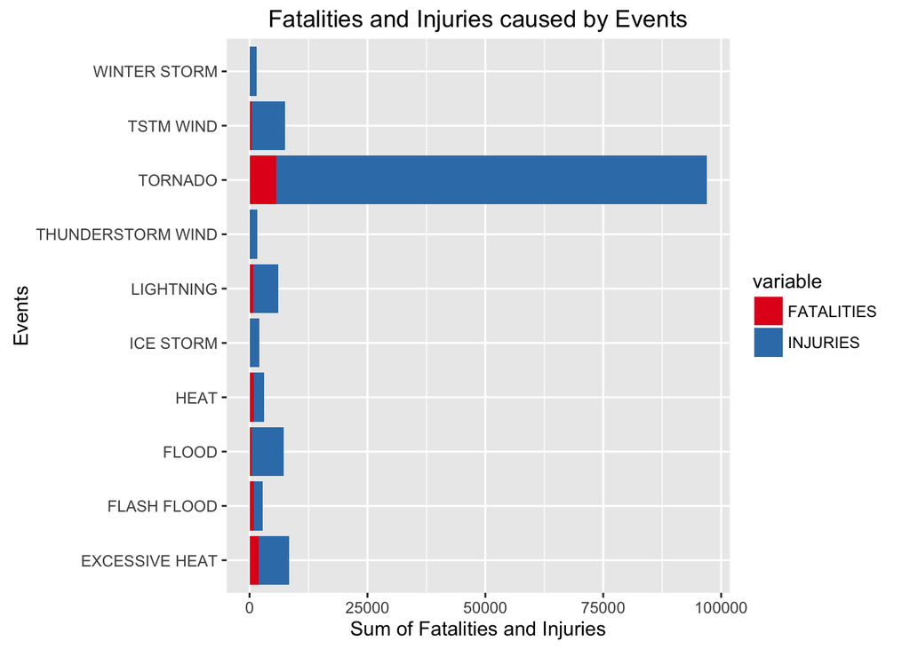

```r
library(ggplot2)
library(reshape2)
# Make summation of fatalities and injuries by event type
PLOT_DATA <- FILTERED_DATA[, lapply(.SD,sum), by = EVTYPE, .SDcols=c('FATALITIES', 'INJURIES')]
PLOT_DATA <- melt(PLOT_DATA[head(order(-(FATALITIES + INJURIES)), 10)], id.vars = "EVTYPE", measure.vars= c("FATALITIES", "INJURIES"))

ggplot(data = PLOT_DATA, aes(y = value, x = EVTYPE, fill = variable)) +
  geom_bar(stat = "identity") +
  scale_fill_brewer(palette = "Set1") +
  coord_flip() +
  xlab("Events") +
  ylab("Sum of Fatalities and Injuries") +
  ggtitle("Fatalities and Injuries caused by Events")
```

According to this chart, ‘TORNADO’ is the most harmful event to fatalities and injuries.

### Across the United States, which types of events have the greatest economic consequences?

```r
library(ggplot2)
```